# Lab 6

Math 241, Week 8

```r
#install.packages("leaflet")

# Put all necessary libraries here
library(tidyverse)
library(leaflet)
library(tidycensus)
library(ggplot2)
library(dplyr)
library(readr)
library(lubridate)
library(tmap)
library(sf)
```

## Due: Friday, March 22nd at 8:30am

## Goals of this lab

- Practice creating static and interactive choropleth maps.

### Problem 1: Mapping Bike Rides in Portland

For this problem we will return to the biketown dataset.

1. Grab the code from activity 9, Problem 1 to read the data directly from Biketown’s API- make sure to keep the longitude and latitude of the start of each ride (`StartLatitude`, `StartLongitude`).

```r
biketown_data <- bind_rows(readr::read_csv("https://s3.amazonaws.com/biketown-tripdata-public/2017_01.csv"),
                           readr::read_csv("https://s3.amazonaws.com/biketown-tripdata-public/2017_07.csv"),
                           readr::read_csv("https://s3.amazonaws.com/biketown-tripdata-public/2017_11.csv")) %>%
  select(StartDate, StartTime, EndDate, EndTime, Distance_Miles,
         BikeID, StartLatitude, StartLongitude)
```

2. Create an interactive map of the start point of the rides using the `leaflet` package. Make sure to include a legend and a title. What do you notice about the distribution of rides?

```r
biketown_map <- leaflet() %>%
  addTiles() %>%
  addMarkers(data = biketown_data, lng = ~StartLongitude, lat = ~StartLatitude)

#biketown_map
```

3. Using the `lubridate` package, create a variable, `month`, indicating the month of each variable.

Add this variable to your interactive map using color. Make sure to include a legend and be mindful of your color palette choice. Do ride locations vary by months of the year?

```r
# Convert StartDate column to standard date-time format
biketown_data <- biketown_data %>%
  mutate(
    StartDate = mdy(StartDate)
  )

# Now create the month variable and a season variable
biketown_data <- biketown_data %>%
  mutate(
    month = month(StartDate)
  ) %>%
   mutate(
    month = month(StartDate),
    season = case_when(
      month %in% c(12, 1, 2) ~ "Winter",
      month %in% c(3, 4, 5) ~ "Spring",
      month %in% c(6, 7, 8) ~ "Summer",
      month %in% c(9, 10, 11) ~ "Fall"
    )
  )


#
biketown_map <- leaflet() %>%
  addTiles() %>%
  addCircleMarkers(
    data = biketown_data,
    lng = ~StartLongitude,
    lat = ~StartLatitude
   # ,color = season  --- this refused to work and said the season object did not exist despite it appearing in the data frame
  )
```

### Problem 2: Choropleth Maps

For this problem, I want you to practice creating choropleth maps. Let’s grab some data using `tidycensus`. Remember that you will have to set up an [API key](https://api.census.gov/data/key_signup.html).

```r
api_key <- "5fe0ca3703f6190c4f956fd1f3addb987986d607"
```

1. Let’s grab data on the median gross rent (`B25064_001`) from the American Community Survey for Multnomah county, Oregon. I want you to do data pulls at three geography resolutions: county subdivision, tract, and block group.

```r
#looking at variables reall quick
v21 <- load_variables(2021, "acs5", cache = TRUE)
View(v21)
```

```r
#pulling county level data
mult_county <- get_acs(geography = "county",
              county = "multnomah",
              variables = c(median_gross_rent = "B25064_001"),
              geometry = TRUE,
              state = "OR",
              cache_table = TRUE)
#pulling tract level data
mult_tracts <- get_acs(geography = "tract",
              county = "multnomah",
              variables = c(median_gross_rent = "B25064_001"),
              geometry = TRUE,
              state = "OR",
              cache_table = TRUE)
#pulling block group level data
mult_blocks <- get_acs(geography = "block group",
              county = "multnomah",
              variables = c(median_gross_rent = "B25064_001"),
              geometry = TRUE,
              state = "OR",
              cache_table = TRUE)
```

2. Create three choropleth maps of gross rent, one for each geography resolution. What information can we glean from these maps? Also, which resolution seems most useful for this variable? Justify your answer.

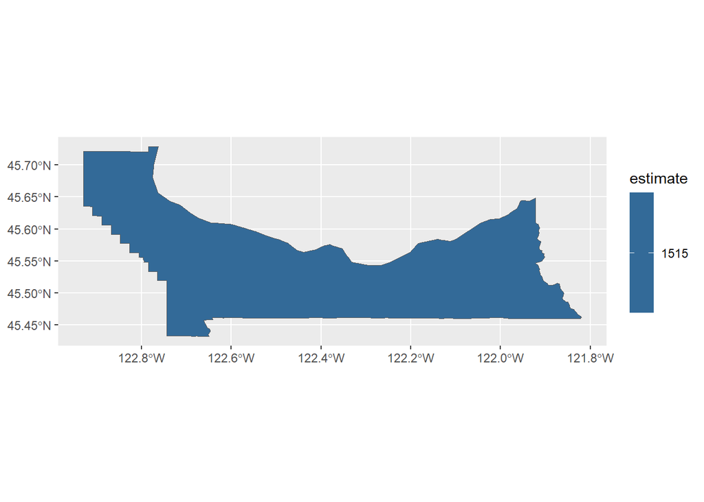

```r
#county level map
ggplot(data = mult_county, aes(geometry = geometry, fill = estimate)) +
  geom_sf() +
  coord_sf()
```

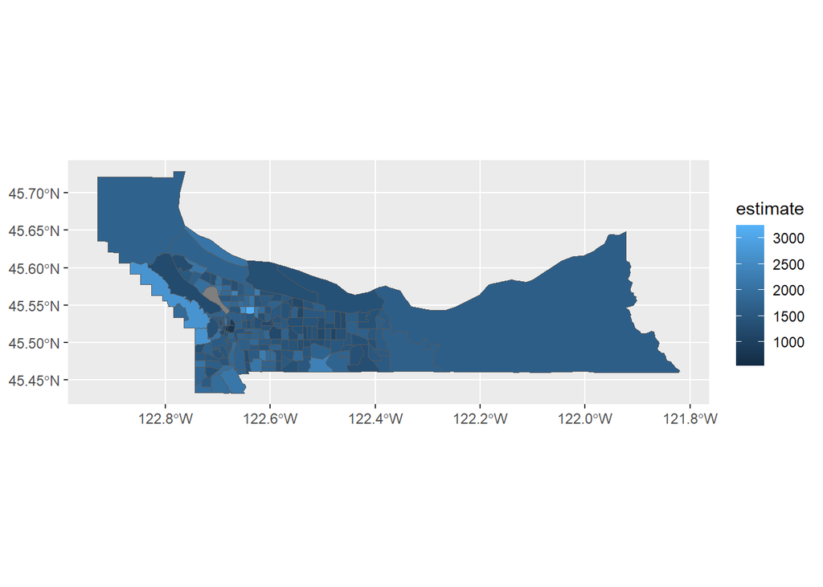

```r
#tract level map
ggplot(data = mult_tracts, aes(geometry = geometry, fill = estimate)) +
  geom_sf() +
  coord_sf()
```

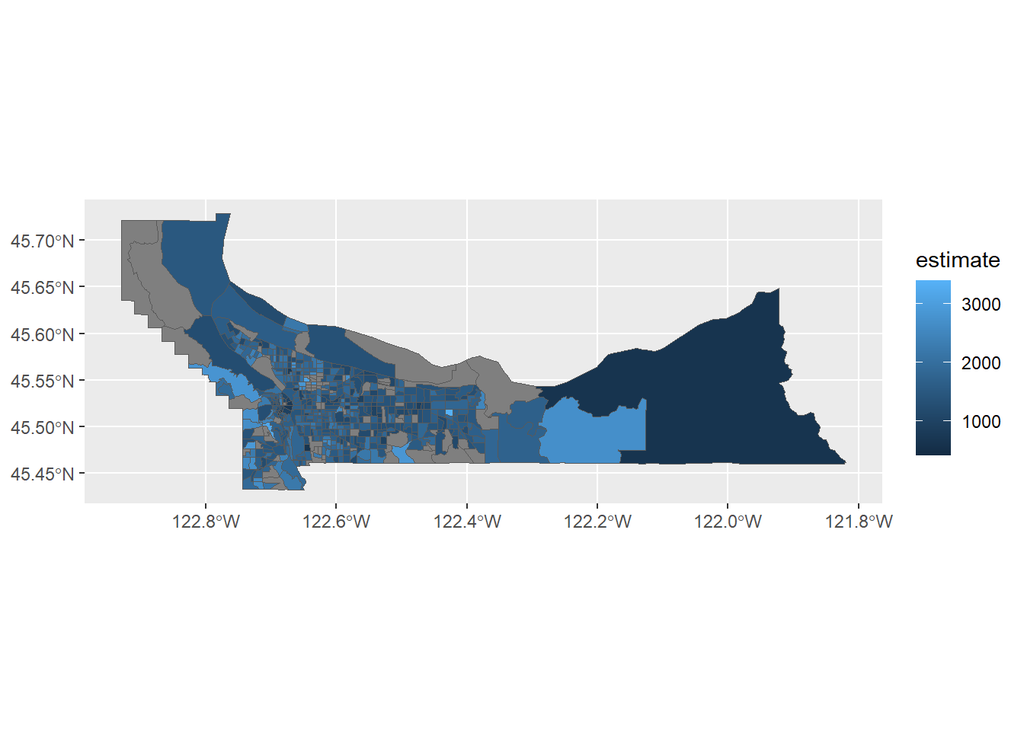

```r
#block-group level map
ggplot(data = mult_blocks, aes(geometry = geometry, fill = estimate)) +
  geom_sf() +
  coord_sf()
```